# IBE PhD Course: R for Bioinformatics

Marina Alvarez & Paula Esteller

7/13/2022

To check what each function does, just add `?` before the name of the function and an explanation of the function will appear:

```r
?read.delim
```

# Importing the dataset

```r
dat <- read.table("../GTEx_v8_gene_median_tpm_formatted.gct", header = TRUE)
# You can specify the class for each column, the specific decimal separator, etc.
```

We can use `head` to see the first rows of the dataset:

```r
head(dat)
```

|  | Name | Description | Adipose_Subcutaneous | Adipose_Visceral.Omentum. | AdrenalGland | Artery_Aorta | Artery_Coronary | Artery_Tibial | Bladder | Brain_Amygdala | Brain_Anteriorcingulatecortex.BA24. | Brain_Caudate.basalganglia. | Brain_CerebellarHemisphere | Brain_Cerebellum | Brain_Cortex | Brain_FrontalCortex.BA9. | Brain_Hippocampus | Brain_Hypothalamus | Brain_Nucleusaccumbens.basalganglia. | Brain_Putamen.basalganglia. | Brain_Spinalcord.cervicalc_1. | Brain_Substantianigra | Breast_MammaryTissue | Cells_Culturedfibroblasts | Cells_EBV_transformedlymphocytes | Cervix_Ectocervix | Cervix_Endocervix | Colon_Sigmoid | Colon_Transverse | … |
| --- | --- | --- | --- | --- | --- | --- | --- | --- | --- | --- | --- | --- | --- | --- | --- | --- | --- | --- | --- | --- | --- | --- | --- | --- | --- | --- | --- | --- | --- | --- |
| 1 | ENSG00000223972.5 | DDX11L1 | 0.00000 | 0.00000 | 0.0000000 | 0.00000 | 0.00000 | 0.00000 | 0.0000000 | 0.0000000 | 0.0000000 | 0.0000000 | 0.0000000 | 0.0000000 | 0.0000000 | 0.0000000 | 0.0000000 | 0.0000000 | 0.0000000 | 0.0000000 | 0.0000000 | 0.0000000 | 0.0000000 | 0.0000 | 0.00000 | 0.00000 | 0.0000000 | 0.0000000 | 0.000000 | … |
| 2 | ENSG00000227232.5 | WASH7P | 4.06403 | 3.37111 | 2.6854900 | 4.04762 | 3.90076 | 3.63963 | 5.1637500 | 1.4385900 | 1.6928500 | 1.5660500 | 4.9923100 | 5.7209900 | 2.4831700 | 2.1466700 | 1.6859900 | 1.7481100 | 1.5389900 | 1.4416700 | 2.7304900 | 1.7419400 | 4.4387600 | 1.6786 | 2.49477 | 5.62935 | 7.0974900 | 4.6477700 | 3.595090 | … |
| 3 | ENSG00000278267.1 | MIR6859_1 | 0.00000 | 0.00000 | 0.0000000 | 0.00000 | 0.00000 | 0.00000 | 0.0000000 | 0.0000000 | 0.0000000 | 0.0000000 | 0.0000000 | 0.0000000 | 0.0000000 | 0.0000000 | 0.0000000 | 0.0000000 | 0.0000000 | 0.0000000 | 0.0000000 | 0.0000000 | 0.0000000 | 0.0000 | 0.00000 | 0.00000 | 0.0000000 | 0.0000000 | 0.000000 | … |
| 4 | ENSG00000243485.5 | MIR1302_2HG | 0.00000 | 0.00000 | 0.0000000 | 0.00000 | 0.00000 | 0.00000 | 0.0000000 | 0.0000000 | 0.0000000 | 0.0242641 | 0.0000000 | 0.0000000 | 0.0273660 | 0.0303822 | 0.0000000 | 0.0247143 | 0.0306685 | 0.0234739 | 0.0000000 | 0.0195261 | 0.0000000 | 0.0000 | 0.00000 | 0.00000 | 0.0000000 | 0.0000000 | 0.000000 | … |
| 5 | ENSG00000237613.2 | FAM138A | 0.00000 | 0.00000 | 0.0000000 | 0.00000 | 0.00000 | 0.00000 | 0.0000000 | 0.0000000 | 0.0000000 | 0.0000000 | 0.0000000 | 0.0000000 | 0.0000000 | 0.0000000 | 0.0000000 | 0.0000000 | 0.0000000 | 0.0000000 | 0.0000000 | 0.0000000 | 0.0000000 | 0.0000 | 0.00000 | 0.00000 | 0.0000000 | 0.0000000 | 0.000000 | … |
| 6 | ENSG00000268020.3 | OR4G4P | 0.00000 | 0.00000 | 0.0363952 | 0.00000 | 0.00000 | 0.00000 | 0.0354698 | 0.0496721 | 0.0535347 | 0.0455724 | 0.0246426 | 0.0372239 | 0.0429845 | 0.0421429 | 0.0529141 | 0.0396660 | 0.0445129 | 0.0484946 | 0.0416046 | 0.0466989 | 0.0300396 | 0.0000 | 0.00000 | 0.00000 | 0.0240885 | 0.0154943 | 0.032754 | … |

You can also check some specifications about the dataset with `class`and `str`

```r
class(dat) # It shows the type of object we have
```

```
## [1] "data.frame"
```

```r
str(dat)
```

```
## 'data.frame':    56200 obs. of  56 variables:
##  $ Name                                : chr  "ENSG00000223972.5" "ENSG00000227232.5" "ENSG00000278267.1" "ENSG00000243485.5" ...
##  $ Description                         : chr  "DDX11L1" "WASH7P" "MIR6859_1" "MIR1302_2HG" ...
##  $ Adipose_Subcutaneous                : num  0 4.06 0 0 0 ...
##  $ Adipose_Visceral.Omentum.           : num  0 3.37 0 0 0 ...
##  $ AdrenalGland                        : num  0 2.69 0 0 0 ...
##  $ Artery_Aorta                        : num  0 4.05 0 0 0 ...
##  $ Artery_Coronary                     : num  0 3.9 0 0 0 ...
##  $ Artery_Tibial                       : num  0 3.64 0 0 0 ...
##  $ Bladder                             : num  0 5.16 0 0 0 ...
##  $ Brain_Amygdala                      : num  0 1.44 0 0 0 ...
##  $ Brain_Anteriorcingulatecortex.BA24. : num  0 1.69 0 0 0 ...
##  $ Brain_Caudate.basalganglia.         : num  0 1.566 0 0.0243 0 ...
##  $ Brain_CerebellarHemisphere          : num  0 4.99 0 0 0 ...
##  $ Brain_Cerebellum                    : num  0 5.72 0 0 0 ...
```

[output cut: 42 more lines]

# Reviewing some basics of R

### Which are the dimensions of the dataset?

You can use `dim`, `nrow` and `ncol` to get some information about the data you have in terms of its dimension. You can also get this information at the Environment panel, from the specific dataframe name `dat`. Also, when you are using RMarkdown you can see this when doing `head(dat)` or simply `dat` at the bottom left of the output table (see above). `View(dat)` will open a spreadsheet-style data viewer.

```r
dim(dat) # Dimensions: rows and columns
```

```
## [1] 56200    56
```

```r
nrow(dat) # Number of rows
```

```
## [1] 56200
```

```r
ncol(dat) # Number of columns
```

```
## [1] 56
```

### Check the header of your dataset

You can check the header with either `colnames` or `names`.

```r
colnames(dat)
```

```
##  [1] "Name"
##  [2] "Description"
##  [3] "Adipose_Subcutaneous"
##  [4] "Adipose_Visceral.Omentum."
##  [5] "AdrenalGland"
##  [6] "Artery_Aorta"
##  [7] "Artery_Coronary"
##  [8] "Artery_Tibial"
##  [9] "Bladder"
## [10] "Brain_Amygdala"
## [11] "Brain_Anteriorcingulatecortex.BA24."
## [12] "Brain_Caudate.basalganglia."
## [13] "Brain_CerebellarHemisphere"
## [14] "Brain_Cerebellum"
## [15] "Brain_Cortex"
```

[output cut: 41 more lines]

# Some metrics of the dataset

To get the minimum and maximum expression values of the first tissue of the dataset, you can do:

```r
max(dat$Adipose_Subcutaneous)
```

```
## [1] 34957.8
```

```r
min(dat$Adipose_Subcutaneous)
```

```
## [1] 0
```

```r
range(dat$Adipose_Subcutaneous)
```

```
## [1]     0.0 34957.8
```

Let’s make a loop to know the ID of each column (FYI: we do this to practice the concept of loop. If we wanted to retrieve the names of the IDs of each column we could simply do `colnames(dat)` or `names(dat)` as shown before).

```r
for (i in 1:ncol(dat)) {
  print(names(dat)[i])
}
```

```
## [1] "Name"
## [1] "Description"
## [1] "Adipose_Subcutaneous"
## [1] "Adipose_Visceral.Omentum."
## [1] "AdrenalGland"
## [1] "Artery_Aorta"
## [1] "Artery_Coronary"
## [1] "Artery_Tibial"
## [1] "Bladder"
## [1] "Brain_Amygdala"
## [1] "Brain_Anteriorcingulatecortex.BA24."
## [1] "Brain_Caudate.basalganglia."
## [1] "Brain_CerebellarHemisphere"
## [1] "Brain_Cerebellum"
## [1] "Brain_Cortex"
```

[output cut: 41 more lines]

Now, if we want to look for the number of genes with **zero** expression in the Liver, we could do the following:

```r
counter <- 0 # Set counter to 0
for (i in 1:nrow(dat)) { # For each of the genes in the dataset
  if (dat$Liver[i] == 0) # If their expression is 0
    counter <- counter + 1 # Add +1 to the counter
}

#There are several ways to print the output:
print(paste("There are", counter, "number of genes with an expression equal to zero."))
```

```
## [1] "There are 29640 number of genes with an expression equal to zero."
```

```r
print(paste("There are", counter, "number of genes with an expression equal to zero.", sep = "~"))
```

```
## [1] "There are~29640~number of genes with an expression equal to zero."
```

```r
print(paste0("There are", counter, "number of genes with an expression equal to zero."))
```

```
## [1] "There are29640number of genes with an expression equal to zero."
```

This can be done using `dplyr`, a package for working with data frame like objects in a fast and memory-efficient way.

```r
### Dplyr alternative
dat %>%
  select(Liver) %>%
  filter(Liver == 0) %>%
  count()
```

| n |
| --- |
| 29640 |

```r
# One-liner
x <- length(dat$Liver[which(dat$Liver==0)])
x
```

```
## [1] 29640
```

> Exercice: Report the highest mean expression value and its corresponding tissue using a for loop (tip: remember the first tissue starts in the 3rd column!)

```r
# You can type your code here:
```

# Apply family

For loops are easy-to-understand and code so one might be tented to used them too much. As opposed to other programming languages, R is not particularly good at running loops an so they might be good for low-intensity iterations, but they are not generally recommended with high-dimensional data. There are some other functions that are specifically designed to substitute loops in R. One of these sets of functions fall within the **apply family**.

This is how they can be used:

```r
apply(X = dat[3:ncol(dat)],MARGIN = 2, FUN = mean) # Mean tissue expression
```

```
##                 Adipose_Subcutaneous            Adipose_Visceral.Omentum.
##                             16.68456                             16.29542
##                         AdrenalGland                         Artery_Aorta
##                             16.94404                             16.70624
##                      Artery_Coronary                        Artery_Tibial
##                             16.19193                             16.74076
##                              Bladder                       Brain_Amygdala
##                             16.10108                             17.04208
##  Brain_Anteriorcingulatecortex.BA24.          Brain_Caudate.basalganglia.
##                             17.15199                             17.21208
##           Brain_CerebellarHemisphere                     Brain_Cerebellum
##                             17.14512                             17.32882
##                         Brain_Cortex             Brain_FrontalCortex.BA9.
##                             17.39616                             17.26294
##                    Brain_Hippocampus                   Brain_Hypothalamus
##                             17.10222                             16.78851
## Brain_Nucleusaccumbens.basalganglia.          Brain_Putamen.basalganglia.
##                             17.21402                             17.25448
##        Brain_Spinalcord.cervicalc_1.                Brain_Substantianigra
##                             16.88317                             17.00186
##                 Breast_MammaryTissue            Cells_Culturedfibroblasts
##                             15.98844                             16.61263
##     Cells_EBV_transformedlymphocytes                    Cervix_Ectocervix
##                             16.50964                             15.68922
##                    Cervix_Endocervix                        Colon_Sigmoid
##                             16.60874                             16.88430
##                     Colon_Transverse   Esophagus_GastroesophagealJunction
##                             15.91779                             16.75236
##                     Esophagus_Mucosa                 Esophagus_Muscularis
##                             16.48811                             16.92073
##                        FallopianTube                Heart_AtrialAppendage
##                             16.58842                             16.82638
##                  Heart_LeftVentricle                        Kidney_Cortex
##                             17.01110                             16.21261
##                       Kidney_Medulla                                Liver
##                             16.91249                             16.00054
##                                 Lung                   MinorSalivaryGland
##                             15.93637                             15.09430
##                      Muscle_Skeletal                         Nerve_Tibial
##                             16.58643                             16.97659
##                                Ovary                             Pancreas
##                             16.79196                             16.44551
##                            Pituitary                             Prostate
##                             15.96178                             16.08950
##       Skin_NotSunExposed.Suprapubic.            Skin_SunExposed.Lowerleg.
##                             16.68538                             16.77985
##         SmallIntestine_TerminalIleum                               Spleen
##                             15.64885                             16.33650
##                              Stomach                               Testis
##                             15.10296                             17.28852
##                              Thyroid                               Uterus
##                             16.48153                             16.59886
##                               Vagina                           WholeBlood
##                             15.70683                             15.23926
```

```r
lapply(3:ncol(dat), function(x) mean(dat[,x])) # Lapply() always returns a list
```

```
## [[1]]
## [1] 16.68456
##
## [[2]]
## [1] 16.29542
##
## [[3]]
## [1] 16.94404
##
## [[4]]
## [1] 16.70624
##
## [[5]]
## [1] 16.19193
##
## [[6]]
## [1] 16.74076
##
## [[7]]
## [1] 16.10108
##
## [[8]]
## [1] 17.04208
##
## [[9]]
## [1] 17.15199
##
## [[10]]
## [1] 17.21208
##
## [[11]]
## [1] 17.14512
##
## [[12]]
## [1] 17.32882
##
## [[13]]
## [1] 17.39616
##
## [[14]]
```

[output cut: 106 more lines]

```
##
## [[50]]
## [1] 17.28852
##
## [[51]]
## [1] 16.48153
##
## [[52]]
## [1] 16.59886
##
## [[53]]
## [1] 15.70683
##
## [[54]]
## [1] 15.23926
```

```r
sapply(3:ncol(dat), function(x) mean(dat[,x])) # Sapply() returns a vector
```

```
##  [1] 16.68456 16.29542 16.94404 16.70624 16.19193 16.74076 16.10108 17.04208
##  [9] 17.15199 17.21208 17.14512 17.32882 17.39616 17.26294 17.10222 16.78851
## [17] 17.21402 17.25448 16.88317 17.00186 15.98844 16.61263 16.50964 15.68922
## [25] 16.60874 16.88430 15.91779 16.75236 16.48811 16.92073 16.58842 16.82638
## [33] 17.01110 16.21261 16.91249 16.00054 15.93637 15.09430 16.58643 16.97659
## [41] 16.79196 16.44551 15.96178 16.08950 16.68538 16.77985 15.64885 16.33650
## [49] 15.10296 17.28852 16.48153 16.59886 15.70683 15.23926
```

> Exercice: Find the gene with the highest mean expression using `apply family`functions.

```r
# You can type your code here:
```

> Exercice. Which is the tissue which has the highest FOXP2 expression?

```r
# You can type your code here:
```

# dplyr & tidyr

Reshaping a dataframe with `pivot_longer()` and/or `pivot_wider()`. Here we will use `pivot_longer()` to put all the expression values into 1 column, grouping all the tissues into another.

```r
dat %>%
  pivot_longer(cols = 3:ncol(dat), names_to = "Tissue", values_to = "Expression")
```

| Name | Description | Tissue | Expression |
| --- | --- | --- | --- |
| ENSG00000223972.5 | DDX11L1 | Adipose_Subcutaneous | 0.00000e+00 |
| ENSG00000223972.5 | DDX11L1 | Adipose_Visceral.Omentum. | 0.00000e+00 |
| ENSG00000223972.5 | DDX11L1 | AdrenalGland | 0.00000e+00 |
| ENSG00000223972.5 | DDX11L1 | Artery_Aorta | 0.00000e+00 |
| ENSG00000223972.5 | DDX11L1 | Artery_Coronary | 0.00000e+00 |
| ENSG00000223972.5 | DDX11L1 | Artery_Tibial | 0.00000e+00 |
| ENSG00000223972.5 | DDX11L1 | Bladder | 0.00000e+00 |
| ENSG00000223972.5 | DDX11L1 | Brain_Amygdala | 0.00000e+00 |
| ENSG00000223972.5 | DDX11L1 | Brain_Anteriorcingulatecortex.BA24. | 0.00000e+00 |
| ENSG00000223972.5 | DDX11L1 | Brain_Caudate.basalganglia. | 0.00000e+00 |

[output cut: 9990 more lines]

Once we have reshaped the dataframe, we can filter with `filter()` to select a specific tissue and get the mean expression.

```r
dat %>%
  pivot_longer(cols = 3:ncol(dat), names_to = "Tissue", values_to = "Expression") %>%
  filter(Tissue == "Lung") %>%
  summarise(mean(Expression))
```

| mean(Expression) |
| --- |
| 15.93637 |

Summarise can output other metrics, such as the `min`, `max`, `median`, …

> Exercice. Using the `group_by` function get the mean, median, min and max expression for each tissue.

```r
# You can type your code here:
```

Whatever we have processed with dplyr, we can directly input to ggplot (without saving it into a variable!). For example, let’s plot the expression of genes expressed in `Brain` tissues

[output not shown]

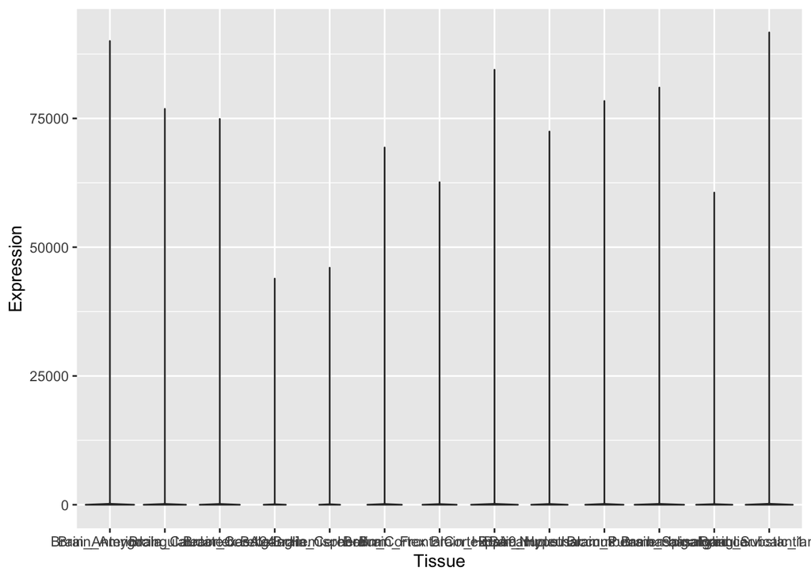

```r
dat %>%
  pivot_longer(cols = 3:ncol(dat), names_to = "Tissue", values_to = "Expression") %>%
  filter(str_detect(Tissue, "^Brain")) %>%
  ggplot( aes(x = Tissue, y = Expression)) +
  geom_violin(draw_quantiles = c(0.5))
```

As you can see the plot is not very useful to see differences between tissues. Let’s tume some things.

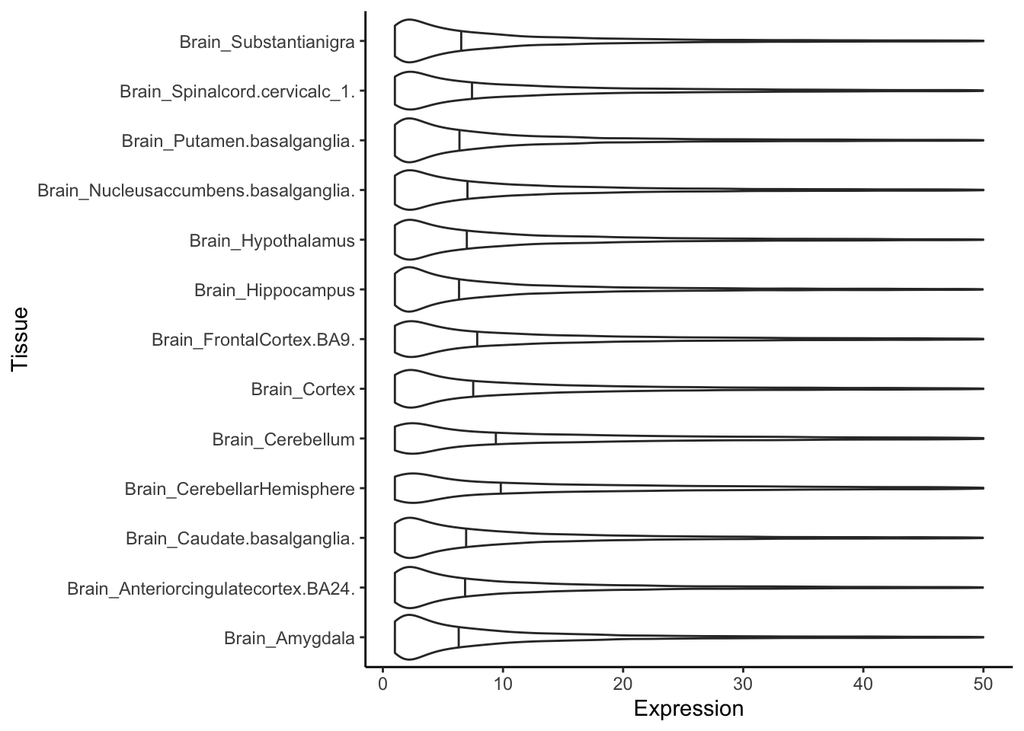

```r
dat %>%
  pivot_longer(cols = 3:ncol(dat), names_to = "Tissue", values_to = "Expression") %>%
  filter(str_detect(Tissue, "^Brain")) %>%
  ggplot( aes(x = Tissue, y = Expression)) +
  geom_violin(draw_quantiles = c(0.5)) +
  ylim(1,50) +
  coord_flip() +
  theme_classic()
```

What if we want to have a new column, the “Organ” column? One organ will have multiple tissues.

```r
names(dat)
```

```
##  [1] "Name"
##  [2] "Description"
##  [3] "Adipose_Subcutaneous"
##  [4] "Adipose_Visceral.Omentum."
##  [5] "AdrenalGland"
##  [6] "Artery_Aorta"
##  [7] "Artery_Coronary"
##  [8] "Artery_Tibial"
##  [9] "Bladder"
## [10] "Brain_Amygdala"
## [11] "Brain_Anteriorcingulatecortex.BA24."
## [12] "Brain_Caudate.basalganglia."
## [13] "Brain_CerebellarHemisphere"
## [14] "Brain_Cerebellum"
## [15] "Brain_Cortex"
```

[output cut: 41 more lines]

```r
OrganTissue <- dat %>%
  head() %>%
  pivot_longer(cols = 3:ncol(dat), names_to = "Tissue", values_to = "Expression") %>%
  separate(col = Tissue, into = c("Organ", "Tissue2"), sep = "_",
           remove = TRUE,  #remove `Tissue` column
           extra = "merge", #To only split a specified number of times `extra = merge`
           fill = "left")  %>% #To fill with NAs the
  mutate(Organ = coalesce(Organ, Tissue2) # Fill NAs from Organ column with values from Tissue2 column
         )
```

And now we will plot the counts of tissues by organ. We will use this to show some examples on how to tune a plot.

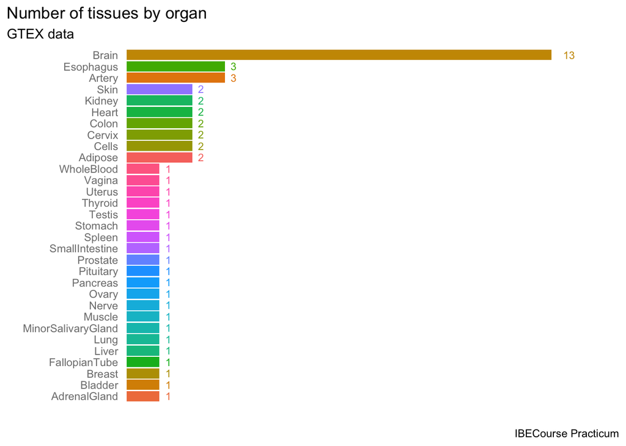

```r
OrganTissue %>%
  group_by(Organ) %>%
  summarise(CountTissues = n_distinct(Tissue2)) %>%
  ggplot(aes(x = reorder(Organ, CountTissues), y = CountTissues, fill = Organ)) +
  geom_col() +
  coord_flip() + #we flip the plot so the original X axis labels are easy to read and we do not have to rotate our heads
  scale_y_continuous(expand = c(0.005, 0), limits = c(0,15)) +
  geom_text(aes(label = CountTissues, hjust = -1, color = Organ), size = 3) +
  labs(title = "Number of tissues by organ", subtitle = "GTEX data", caption = "IBECourse Practicum") + # Add title, subtitle and caption
  ylab("") + xlab("") + #Remove x and y axis labels (possible to do when there is an explanatory plot title)
  theme_classic() +
  theme(legend.position = "none", #Remove legen since there are already the labels on the axis to identify each organ
        plot.title.position = "plot", #Align the title and subtitle to the plot, not the vertical axis
        axis.line = element_blank(), #remove axis lines
        axis.ticks = element_blank(), #remove axis ticks
        axis.text.x = element_blank(), #remove X axis labels
        axis.text.y = element_text(color = "grey50")
        )
```

# Functions

You can write your own functions in order to make repetitive operations using a single command. Actually, this is good practice for making reproducible results.

For example, if we want to obtain the maximum expression of a gene we could write a function like this:

```r
max_gene_expression <- function(gene_name) {
  coord_gene <- which(dat$Description == gene_name)

  return(print(paste0("Max ", gene_name, " expression: ", max(dat[coord_gene,3:ncol(dat)]), " TPM.")))
}
```

The `max_gene_expression()` function has been defined and now it can run with any gene we’d like to add:

```r
max_gene_expression(gene_name = "BRCA1")
```

```
## [1] "Max BRCA1 expression: 19.7684 TPM."
```

```r
max_gene_expression(gene_name = "CTCF")
```

```
## [1] "Max CTCF expression: 53.0068 TPM."
```

> Exercice: Improve the `max_gene_expression()` function so that it can provide the highest expression value for a given gene and also its corresponding tissue.

```r
# You can type your code here:
```

> Exercice: Similar to the `max_gene_expression()` function, create a function that from the name of a gene and a tissue, yields its corresponding expression value. Note that this function will take two arguments.

```r
# You can type your code here:
```

# Data Visualization - ggplot

# Practical tips

- Save your Rsession
- Remove all plots
- Remove environment